# Simple example

Daniel P. Palomar Hong Kong University of Science and Technology (HKUST)

2019-01-08

> This note contains an example under consideration by Alexis Nortier.

# Risk-parity portfolio formulation

The risk-parity portfolio formulation is of the form [1][2]:
$$\begin{array}{ll}
\underset{\mathbf{w}}{\textsf{minimize}} & R(\mathbf{w})\\
\textsf{subject to} & \mathbf{1}^T\mathbf{w}=1\\
& \mathbf{w}\ge\mathbf{0},
\end{array}$$
where the risk term is of the form (double summation) $R(\mathbf{w}) = \sum_{i,j=1}^{N}(g_{ij}(\mathbf{w}))^{2}$ or simply (single summation) $R(\mathbf{w}) = \sum_{i=1}^{N}(g_{i}(\mathbf{w}))^{2}$.

# Parameter definition for the test

Consider the following parameters:
$$\boldsymbol{\Sigma} = \left[
\begin{array}{ccc}
1.0000 & 0.0015 & -0.0119\\
0.0015 & 1.0000 & -0.0308\\
-0.0119 & -0.0308 & 1.0000
\end{array}
\right]$$
$$\mathbf{b} = \left[
\begin{array}{c}
0.1594 \\
0.0126 \\
0.8280
\end{array}
\right]$$
and the corresponding code:

```r
Sigma <- rbind(c(1.0000, 0.0015, -0.0119),
               c(0.0015, 1.0000, -0.0308),
               c(-0.0119, -0.0308, 1.0000))
b <- c(0.1594, 0.0126, 0.8280)
```

The optimal solution is known to be
$$\mathbf{w}^\star = \left[
\begin{array}{c}
0.2799 \\
0.0877 \\
0.6324
\end{array}
\right],$$
but the Matlab implementation seems to converge to
$$\mathbf{w} = \left[
\begin{array}{c}
0.3106 \\
0.0000 \\
0.6895
\end{array}
\right].$$
Let’s explore this problem with the R package riskParityPortfolio.

# Vanilla formulation

This problem is a vanilla formulation because it just contains the risk-parity term subject to the budget constraint and the no-shortselling constraint. Therefore, it can be reformulated as a convex problem and the global optimal solution can be obtained:

```r
library(riskParityPortfolio)

res <- riskParityPortfolio(Sigma, b = b)
res$w
```

```
#> [1] 0.27986280 0.08774909 0.63238811
```

```r
res$risk_contribution/b
```

```
#> [1] 0.478381 0.478381 0.478381
```

# Formulation “rc-over-var vs b”

Even though we really have a vanilla formulation, we can still consider a direct nonconvex formulation. Consider the risk expression:
$$R(\mathbf{w}) = \sum_{i=1}^{N}\left(\frac{w_{i}\left(\boldsymbol{\Sigma}\mathbf{w}\right)_i}{\mathbf{w}^T\boldsymbol{\Sigma}\mathbf{w}}-b_i\right)^{2}.$$
The general solver `alabama` is sensitive to the initial point in this formulation (the first case gets stuck in a local minimum):

```r
set.seed(234)
res_ala1 <- riskParityPortfolio(Sigma, b = b, w0 = b,
                                formulation = "rc-over-var vs b",
                                method = "alabama")
res_ala1$w
```

```
#> [1] 3.105582e-01 5.543940e-08 6.894418e-01
```

```r
tail(res_ala1$obj_fun, 1)
```

```
#> [1] 0.0002381401
```

```r
res_ala2 <- riskParityPortfolio(Sigma, b = b, w0 = c(1, 1, 1)/3,
                                formulation = "rc-over-var vs b",
                                method = "alabama")
res_ala2$w
```

```
#> [1] 0.27980257 0.08789919 0.63229830
```

```r
tail(res_ala2$obj_fun, 1)
```

```
#> [1] 4.202766e-09
```

```r
res_ala3 <- riskParityPortfolio(Sigma, b = b, w0 = (w0 <- runif(3))/sum(w0),
                                formulation = "rc-over-var vs b",
                                method = "alabama")
res_ala3$w
```

```
#> [1] 0.27985991 0.08775626 0.63238382
```

```r
tail(res_ala3$obj_fun, 1)
```

```
#> [1] 9.590756e-12
```

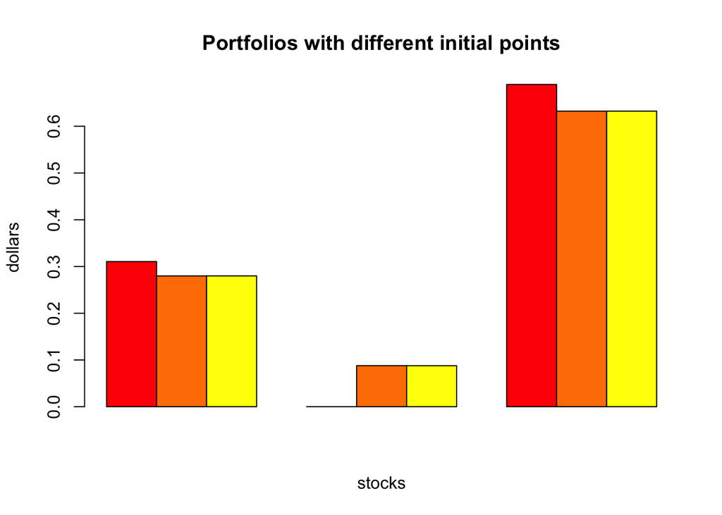

```r
# plot the portfolios
barplot(rbind(res_ala1$w, res_ala2$w, res_ala3$w),
        main = "Portfolios with different initial points",
        xlab = "stocks", ylab = "dollars", beside = TRUE, col = heat.colors(3))
```

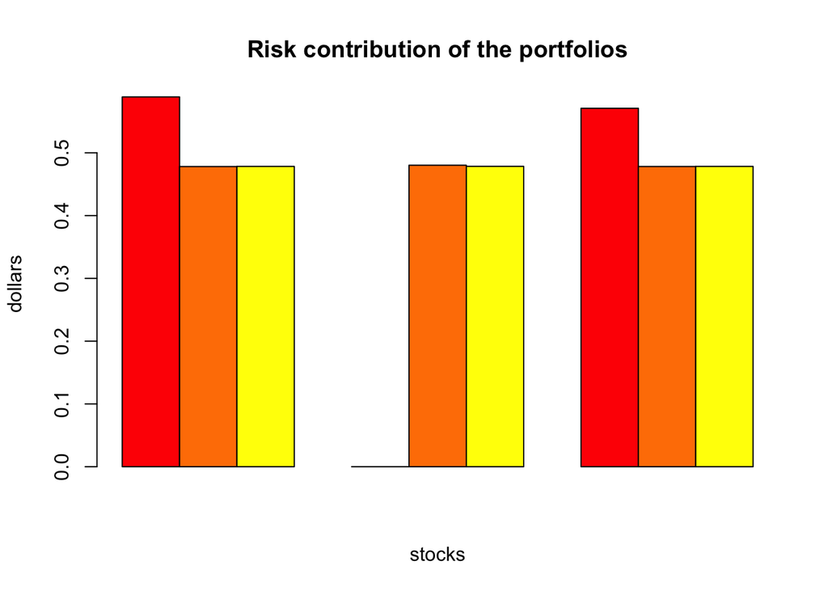

```r
# plot the risk contributions
barplot(rbind(res_ala1$risk_contribution/b, res_ala2$risk_contribution/b, res_ala3$risk_contribution/b),
        main = "Risk contribution of the portfolios",
        xlab = "stocks", ylab = "dollars", beside = TRUE,  col = heat.colors(3))
```

The SCA method gives the same results:

```r
set.seed(234)
res_sca1 <- riskParityPortfolio(Sigma, b = b, w0 = b,
                                formulation = "rc-over-var vs b",
                                method = "sca")
res_sca1$w
```

```
#> [1] 3.105589e-01 1.260029e-10 6.894411e-01
```

```r
tail(res_sca1$obj_fun, 1)
```

```
#> [1] 0.00023814
```

```r
res_sca2 <- riskParityPortfolio(Sigma, b = b, w0 = c(1, 1, 1)/3,
                                formulation = "rc-over-var vs b",
                                method = "sca")
res_sca2$w
```

```
#> [1] 0.27986279 0.08774911 0.63238810
```

```r
tail(res_sca2$obj_fun, 1)
```

```
#> [1] 1.324942e-16
```

```r
res_sca3 <- riskParityPortfolio(Sigma, b = b, w0 = (w0 <- runif(3))/sum(w0),
                                formulation = "rc-over-var vs b",
                                method = "sca")
res_sca3$w
```

```
#> [1] 0.27986276 0.08774918 0.63238806
```

```r
tail(res_sca3$obj_fun, 1)
```

```
#> [1] 1.573911e-15
```

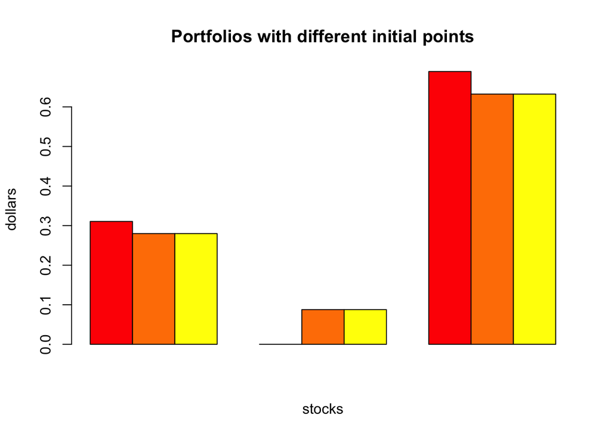

```r
# plot the portfolios
barplot(rbind(res_sca1$w, res_sca2$w, res_sca3$w),
        main = "Portfolios with different initial points",
        xlab = "stocks", ylab = "dollars", beside = TRUE, col = heat.colors(3))
```

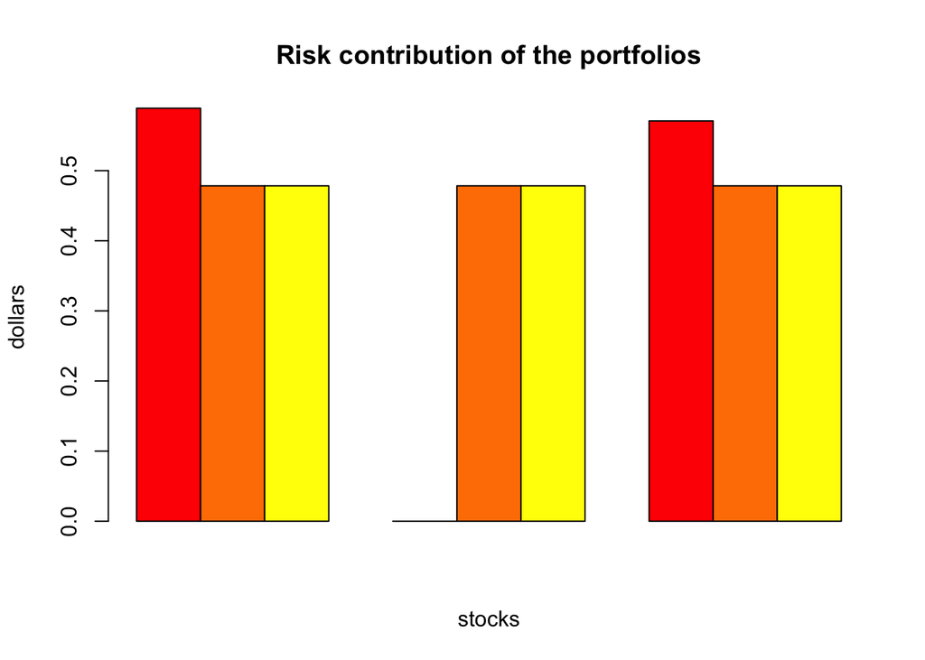

```r
# plot the risk contributions
barplot(rbind(res_sca1$risk_contribution/b, res_sca2$risk_contribution/b, res_sca3$risk_contribution/b),
        main = "Risk contribution of the portfolios",
        xlab = "stocks", ylab = "dollars", beside = TRUE,  col = heat.colors(3))
```

# Formulation “rc-over-sd vs b-times-sd”

Consider now the risk expression:
$$R(\mathbf{w}) = \sum_{i=1}^{N}\left(\frac{w_{i}\left(\boldsymbol{\Sigma}\mathbf{w}\right)_i}{\sqrt{\mathbf{w}^T\boldsymbol{\Sigma}\mathbf{w}}}-b_i\sqrt{\mathbf{w}^T\boldsymbol{\Sigma}\mathbf{w}}\right)^{2} = \sum_{i=1}^{N}\left(\frac{r_i}{\sqrt{\mathbf{1}^T\mathbf{r}}}-b_i\sqrt{\mathbf{1}^T\mathbf{r}}\right)^{2}.$$

The general solver `alabama` is again sensitive to the initial point in this formulation (the third case gets stuck in a local minimum):

```r
set.seed(234)
res_ala1 <- riskParityPortfolio(Sigma, b = b, w0 = b,
                                formulation = "rc-over-sd vs b-times-sd",
                                method = "alabama")
res_ala1$w
```

```
#> [1] 0.27986397 0.08774612 0.63238991
```

```r
tail(res_ala1$obj_fun, 1)
```

```
#> [1] 7.827213e-13
```

```r
res_ala2 <- riskParityPortfolio(Sigma, b = b, w0 = c(1, 1, 1)/3,
                                formulation = "rc-over-sd vs b-times-sd",
                                method = "alabama")
res_ala2$w
```

```
#> [1] 0.27984754 0.08779533 0.63235712
```

```r
tail(res_ala2$obj_fun, 1)
```

```
#> [1] 2.110713e-10
```

```r
res_ala3 <- riskParityPortfolio(Sigma, b = b, w0 = (w0 <- runif(3))/sum(w0),
                                formulation = "rc-over-sd vs b-times-sd",
                                method = "alabama")
res_ala3$w
```

```
#> [1] 0.48186292 0.50518794 0.01294915
```

```r
tail(res_ala3$obj_fun, 1)
```

```
#> [1] 0.5110162
```

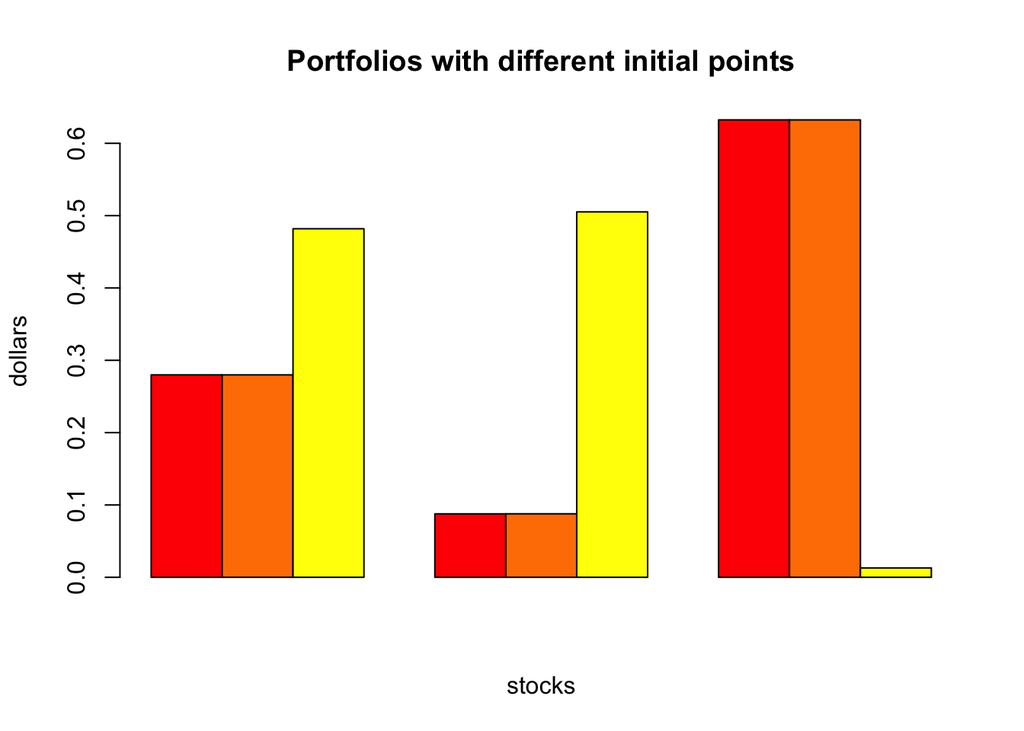

```r
# plot the portfolios
barplot(rbind(res_ala1$w, res_ala2$w, res_ala3$w),
        main = "Portfolios with different initial points",
        xlab = "stocks", ylab = "dollars", beside = TRUE, col = heat.colors(3))
```

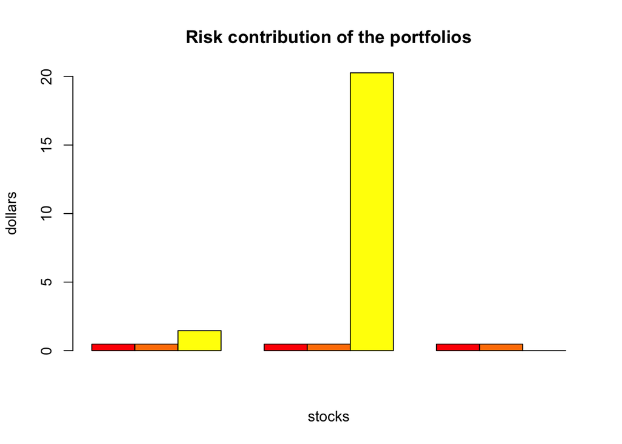

```r
# plot the risk contributions
barplot(rbind(res_ala1$risk_contribution/b, res_ala2$risk_contribution/b, res_ala3$risk_contribution/b),
        main = "Risk contribution of the portfolios",
        xlab = "stocks", ylab = "dollars", beside = TRUE,  col = heat.colors(3))
```

The SCA method is also sensitive to the initial point (the first case gets stuck in a local minimum):

```r
set.seed(234)
res_sca1 <- riskParityPortfolio(Sigma, b = b, w0 = b,
                                formulation = "rc-over-sd vs b-times-sd",
                                method = "sca")
res_sca1$w
```

```
#> [1] 3.106056e-01 1.260029e-10 6.893944e-01
```

```r
tail(res_sca1$obj_fun, 1)
```

```
#> [1] 0.0001349449
```

```r
res_sca2 <- riskParityPortfolio(Sigma, b = b, w0 = c(1, 1, 1)/3,
                                formulation = "rc-over-sd vs b-times-sd",
                                method = "sca")
res_sca2$w
```

```
#> [1] 0.27986277 0.08774917 0.63238806
```

```r
tail(res_sca2$obj_fun, 1)
```

```
#> [1] 6.307486e-16
```

```r
res_sca3 <- riskParityPortfolio(Sigma, b = b, w0 = (w0 <- runif(3))/sum(w0),
                                formulation = "rc-over-sd vs b-times-sd",
                                method = "sca")
res_sca3$w
```

```
#> [1] 0.27986278 0.08774914 0.63238808
```

```r
tail(res_sca3$obj_fun, 1)
```

```
#> [1] 2.504676e-16
```

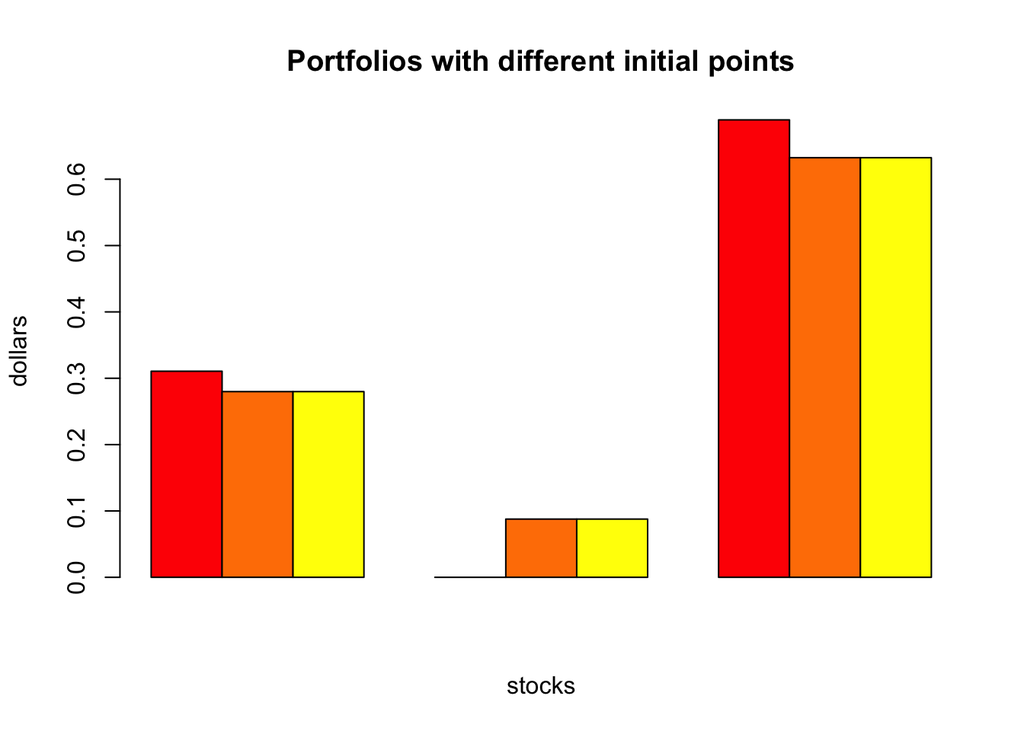

```r
# plot the portfolios
barplot(rbind(res_sca1$w, res_sca2$w, res_sca3$w),
        main = "Portfolios with different initial points",
        xlab = "stocks", ylab = "dollars", beside = TRUE, col = heat.colors(3))
```

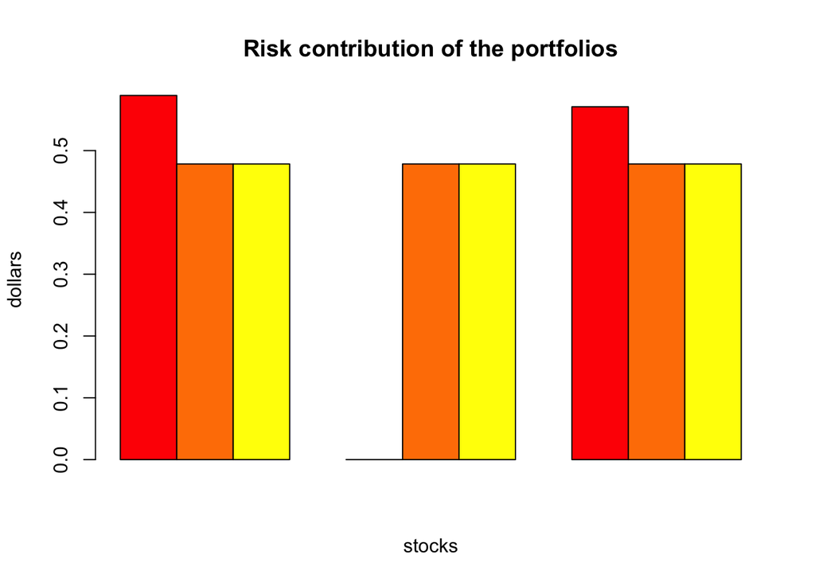

```r
# plot the risk contributions
barplot(rbind(res_sca1$risk_contribution/b, res_sca2$risk_contribution/b, res_sca3$risk_contribution/b),
        main = "Risk contribution of the portfolios",
        xlab = "stocks", ylab = "dollars", beside = TRUE,  col = heat.colors(3))
```

# Conclusion

The vanilla risk-parity portfolio is a convex problem and it can be solved optimally. However, if instead one uses a direct nonconvex formulation (which is required when having different constrains or additional objectives apart from the risk-parity one), there are local minima.

# References

[1] Y. Feng and D. P. Palomar, “SCRIP: Successive convex optimization methods for risk parity portfolios design,” *IEEE Trans. Signal Processing*, vol. 63, no. 19, pp. 5285–5300, 2015.

[2] Y. Feng and D. P. Palomar, *A Signal Processing Perspective on Financial Engineering*. Foundations and Trends in Signal Processing, Now Publishers, 2016.